# DE Gene Analysis

Ceren Akkaya

```r
library(recount3)
library(edgeR)
```

```r
rse_brain <- readRDS("rse_brain.RDS")
rse_kidney <- readRDS("rse_kidney.RDS")
rse_liver <- readRDS("rse_liver.RDS")
```

```r
assays(rse_brain)$counts <- transform_counts(rse_brain)
```

```r
assays(rse_kidney)$counts <- transform_counts(rse_kidney)
```

```r
assays(rse_liver)$counts <- transform_counts(rse_liver)
```

## QUALITY CONTROL

Parameters have been choosen according to RIN number, Fraction of rRNA, and Percantage of Uniquely Mapped Reads. Other parameters also will be considered in next steps if they have an huge impact on variablity of the data.

Theresholds for QC Parameters:

- RIN Number > 6
- Fraction of rRNA < 10%
- Percantage of Uniquely Mapped Reads > 85%

### Choosing Brain Samples According to QC Parameters:

```r
colData(rse_brain)$gtex.smrin[11]
```

```
## [1] 6.4
```

```r
colData(rse_brain)$gtex.smrin[12]
```

```
## [1] 7.5
```

```r
colData(rse_brain)$gtex.smrin[13]
```

```
## [1] 7.1
```

```r
colData(rse_brain)$gtex.smrrnart[11]
```

```
## [1] 0.0654561
```

```r
colData(rse_brain)$gtex.smrrnart[12]
```

```
## [1] 0.0152067
```

```r
colData(rse_brain)$gtex.smrrnart[13]
```

```
## [1] 0.0527296
```

```r
colData(rse_brain)$"recount_qc.star.uniquely_mapped_reads_%_both"[11]
```

```
## [1] 89
```

```r
colData(rse_brain)$"recount_qc.star.uniquely_mapped_reads_%_both"[12]
```

```
## [1] 91.3
```

```r
colData(rse_brain)$"recount_qc.star.uniquely_mapped_reads_%_both"[13]
```

```
## [1] 89.8
```

### Choosing Kidney Samples According to QC Parameters:

```r
colData(rse_kidney)$gtex.smrin[11]
```

```
## [1] 6.2
```

```r
colData(rse_kidney)$gtex.smrin[12]
```

```
## [1] 5.5
```

The RIN number for sample12 is below the thresehold. Therefore, I will proceed with other samples until it satisfied the thresehold.

```r
colData(rse_kidney)$gtex.smrin[17]
```

```
## [1] 7.8
```

```r
colData(rse_kidney)$gtex.smrin[18]
```

```
## [1] 7.5
```

```r
colData(rse_kidney)$gtex.smrrnart[11]
```

```
## [1] 0.0183518
```

```r
colData(rse_kidney)$gtex.smrrnart[17]
```

```
## [1] 0.00877124
```

```r
colData(rse_kidney)$gtex.smrrnart[18]
```

```
## [1] 0.0282769
```

```r
colData(rse_kidney)$"recount_qc.star.uniquely_mapped_reads_%_both"[11]
```

```
## [1] 88.2
```

```r
colData(rse_kidney)$"recount_qc.star.uniquely_mapped_reads_%_both"[17]
```

```
## [1] 88.9
```

```r
colData(rse_kidney)$"recount_qc.star.uniquely_mapped_reads_%_both"[18]
```

```
## [1] 92.3
```

They are all passing thresehold.

### Choosing Liver Samples According to QC Parameters:

```r
colData(rse_liver)$gtex.smrin[11]
```

```
## [1] 8.2
```

```r
colData(rse_liver)$gtex.smrin[12]
```

```
## [1] 8.5
```

```r
colData(rse_liver)$gtex.smrin[13]
```

```
## [1] 6.2
```

```r
colData(rse_liver)$gtex.smrrnart[11]
```

```
## [1] 0.00923495
```

```r
colData(rse_liver)$gtex.smrrnart[12]
```

```
## [1] 0.00909413
```

```r
colData(rse_liver)$gtex.smrrnart[13]
```

```
## [1] 0.0151062
```

```r
colData(rse_liver)$"recount_qc.star.uniquely_mapped_reads_%_both"[11]
```

```
## [1] 89.1
```

```r
colData(rse_liver)$"recount_qc.star.uniquely_mapped_reads_%_both"[12]
```

```
## [1] 90.7
```

```r
colData(rse_liver)$"recount_qc.star.uniquely_mapped_reads_%_both"[13]
```

```
## [1] 88.2
```

So finally I’ve choose my samples. However, I want to also check another parameter for samples which is Sex. I want all my samples belongs to be same sex. In this way, I might decrease the biological variability of my samples.

```r
colData(rse_brain)$gtex.sex[11]
```

```
## [1] 1
```

```r
colData(rse_brain)$gtex.sex[12]
```

```
## [1] 1
```

```r
colData(rse_brain)$gtex.sex[13]
```

```
## [1] 1
```

```r
colData(rse_kidney)$gtex.sex[11]
```

```
## [1] 2
```

```r
colData(rse_kidney)$gtex.sex[17]
```

```
## [1] 1
```

```r
colData(rse_kidney)$gtex.sex[18]
```

```
## [1] 1
```

```r
colData(rse_liver)$gtex.sex[11]
```

```
## [1] 2
```

```r
colData(rse_liver)$gtex.sex[12]
```

```
## [1] 1
```

```r
colData(rse_liver)$gtex.sex[13]
```

```
## [1] 1
```

As can be seen, Kidney Sample 11 and Liver Sample 11 are different sex. So I have to change them.

- New samples for Kidney will be sample number 17,18 and 20
- And for Liver 12,13,14

## Create DGEList Object

```r
rse_brain_selected <- rse_brain[,c(11,12,13)]
rse_kidney_selected <- rse_kidney[,c(17,18,20)]
rse_liver_selected <- rse_liver[,c(12,13,14)]

counts_brain_selected <- assays(rse_brain_selected)$counts
counts_kidney_selected <- assays(rse_kidney_selected)$counts
counts_liver_selected <- assays(rse_liver_selected)$counts


x <- cbind(counts_brain_selected,counts_kidney_selected,counts_liver_selected)

colnames(x) <- c("Brain11","Brain12","Brain13","Kidney17","Kidney18","Kidney20","Liver12","Liver13","Liver14")

rownames(x) <- rowData(rse_brain_selected)$gene_name
```

```r
y <- DGEList(counts=x)

group <- as.factor(c("Brain","Brain","Brain","Kidney","Kidney","Kidney","Liver","Liver","Liver"))

y$samples$group <- group



y$samples$rin <- as.factor(c(colData(rse_brain_selected)$gtex.smrin,colData(rse_kidney_selected)$gtex.smrin,colData(rse_liver_selected)$gtex.smrin))

y$samples$slice <- as.factor(c(colData(rse_brain_selected)$gtex.smtsd,colData(rse_kidney_selected)$gtex.smtsd,colData(rse_liver_selected)$gtex.smtsd))

y$samples$sex <- as.factor(c(colData(rse_brain_selected)$gtex.sex,colData(rse_kidney_selected)$gtex.sex,colData(rse_liver_selected)$gtex.sex))

y$samples$age <- as.factor(c(colData(rse_brain_selected)$gtex.age,colData(rse_kidney_selected)$gtex.age,colData(rse_liver_selected)$gtex.age))

y$samples$rRNA <- as.factor(c(colData(rse_brain_selected)$gtex.smrrnart,colData(rse_kidney_selected)$gtex.smrrnart,colData(rse_liver_selected)$gtex.smrrnart))

y$samples$mapped <- as.factor(c(colData(rse_brain_selected)$"recount_qc.star.uniquely_mapped_reads_%_both", colData(rse_kidney_selected)$"recount_qc.star.uniquely_mapped_reads_%_both",colData(rse_liver_selected)$"recount_qc.star.uniquely_mapped_reads_%_both"))

y$samples$chrm <- as.factor(c(colData(rse_brain_selected)$"recount_qc.aligned_reads%.chrm", colData(rse_kidney_selected)$"recount_qc.aligned_reads%.chrm",colData(rse_liver_selected)$"recount_qc.aligned_reads%.chrm"))

y
```

```
## An object of class "DGEList"
## $counts
##              Brain11 Brain12 Brain13 Kidney17 Kidney18 Kidney20 Liver12 Liver13
## SNX18P15           0       0       0        0        0        0       0       0
## SNX18P16           0       0       0        0        0        0       0       0
## ANKRD20A12P        0       0       0        0        0        0       0       0
## ANKRD20A15P        0       0       0        0        0        0       0       0
## LOC105379272       0       0       0        0        0        0       0       0
##              Liver14
## SNX18P15           0
## SNX18P16           0
## ANKRD20A12P        0
## ANKRD20A15P        0
## LOC105379272       0
## 54037 more rows ...
##
## $samples
##           group lib.size norm.factors rin
## Brain11   Brain 25327468            1 6.4
## Brain12   Brain 32538624            1 7.5
## Brain13   Brain 29674279            1 7.1
## Kidney17 Kidney 27418612            1 7.8
## Kidney18 Kidney 32007441            1 7.5
## Kidney20 Kidney 26891000            1 6.3
## Liver12   Liver 33297387            1 8.5
## Liver13   Liver 31481536            1 6.2
## Liver14   Liver 33834950            1 7.3
##                                             slice sex   age       rRNA mapped
## Brain11  Brain - Anterior cingulate cortex (BA24)   1 60-69  0.0654561     89
## Brain12        Brain - Spinal cord (cervical c-1)   1 60-69  0.0152067   91.3
## Brain13                  Brain - Substantia nigra   1 50-59  0.0527296   89.8
## Kidney17                          Kidney - Cortex   1 50-59 0.00877124   88.9
## Kidney18                          Kidney - Cortex   1 30-39  0.0282769   92.3
## Kidney20                          Kidney - Cortex   1 60-69  0.0151631     88
## Liver12                                     Liver   1 50-59 0.00909413   90.7
## Liver13                                     Liver   1 60-69  0.0151062   88.2
## Liver14                                     Liver   1 20-29 0.00714291   89.2
##           chrm
## Brain11  28.16
## Brain12   7.62
## Brain13  19.75
## Kidney17 20.54
## Kidney18 14.99
## Kidney20 19.88
## Liver12   9.51
## Liver13  12.79
## Liver14   8.18
```

How many genes have indeed 0 counts that don’t appear in any of the 9 replicates should be checked;

```r
table(rowSums(y$counts==0)==9)
```

```
##
## FALSE  TRUE
## 39224 14818
```

Before filtering counts with 0, my object has 54042 genes

```r
dim(y)
```

```
## [1] 54042     9
```

We have to filter them out because these are the genes are not expressed according to edgeR.It should be done before normalization because normalization is done by looking at what happens to all genes.So the genes with 0 counts has effect on screwing all those calculations.

```r
keep.exprs <- filterByExpr(y, group=group)
y <- y[keep.exprs,, keep.lib.sizes=FALSE]
```

After filtering, dim(y) shows what left which are the genes expressed at least in one samples according to edgeR. They might be pseudogene, non coding ones and the others.

```r
dim(y)
```

```
## [1] 23496     9
```

## NORMALIZATION

Save the table containing count per million in log. This function coming from edgeR itself. It is saved before because in here we save the expression values in log of cpm before the normalization and after this internal function of edgeR (calcNormFactors) is employed to normalize the values.

```r
logcpm_before <- cpm(y, log=TRUE)
```

The key point is to finding a constant for each of the samples that by multiplying all the count values in the samples for constant the trend is to have most of the genes not to change expression;

```r
y <- calcNormFactors(y, method = "TMM")
y
```

```
## An object of class "DGEList"
## $counts
##           Brain11 Brain12 Brain13 Kidney17 Kidney18 Kidney20 Liver12 Liver13
## MIR6859-1      13      20      10       18       11       14       9      21
## WASH7P       1233    1293     845     1725     1122     1381     424     845
## SEPT14P18       9      22      29       12        5       12      20      27
## CICP27          6       7       8       13        8       11       5      13
## LOC729737     440     639    1388     1150      265      399     254     728
##           Liver14
## MIR6859-1       9
## WASH7P        502
## SEPT14P18      24
## CICP27         11
## LOC729737     987
## 23491 more rows ...
##
## $samples
##           group lib.size norm.factors rin
## Brain11   Brain 25263958    1.1337606 6.4
## Brain12   Brain 32493384    1.0689860 7.5
## Brain13   Brain 29622124    1.2667019 7.1
## Kidney17 Kidney 27382163    1.5192104 7.8
## Kidney18 Kidney 31979224    1.3425568 7.5
## Kidney20 Kidney 26861557    1.3380080 6.3
## Liver12   Liver 33273505    0.6061357 8.5
## Liver13   Liver 31452156    0.7158391 6.2
## Liver14   Liver 33818799    0.5500949 7.3
##                                             slice sex   age       rRNA mapped
## Brain11  Brain - Anterior cingulate cortex (BA24)   1 60-69  0.0654561     89
## Brain12        Brain - Spinal cord (cervical c-1)   1 60-69  0.0152067   91.3
## Brain13                  Brain - Substantia nigra   1 50-59  0.0527296   89.8
## Kidney17                          Kidney - Cortex   1 50-59 0.00877124   88.9
## Kidney18                          Kidney - Cortex   1 30-39  0.0282769   92.3
## Kidney20                          Kidney - Cortex   1 60-69  0.0151631     88
## Liver12                                     Liver   1 50-59 0.00909413   90.7
## Liver13                                     Liver   1 60-69  0.0151062   88.2
## Liver14                                     Liver   1 20-29 0.00714291   89.2
##           chrm
## Brain11  28.16
## Brain12   7.62
## Brain13  19.75
## Kidney17 20.54
## Kidney18 14.99
## Kidney20 19.88
## Liver12   9.51
## Liver13  12.79
## Liver14   8.18
```

```r
logcpm_after <- cpm(y, log=TRUE)
```

Before Normalization: This is just the distribution of original count divided by library size and transformed into cpm. The line of boxplot shows the median of each replicate’s expression.

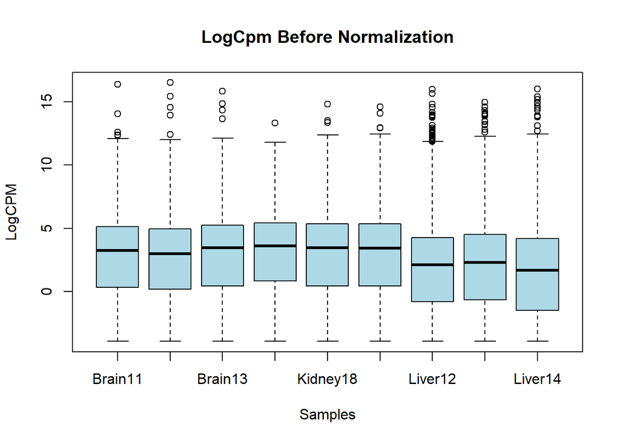

```r
boxplot(logcpm_before, main=("LogCpm Before Normalization"),
        xlab= ("Samples"),
        ylab= ("LogCPM"),
        col=("lightblue"))
```

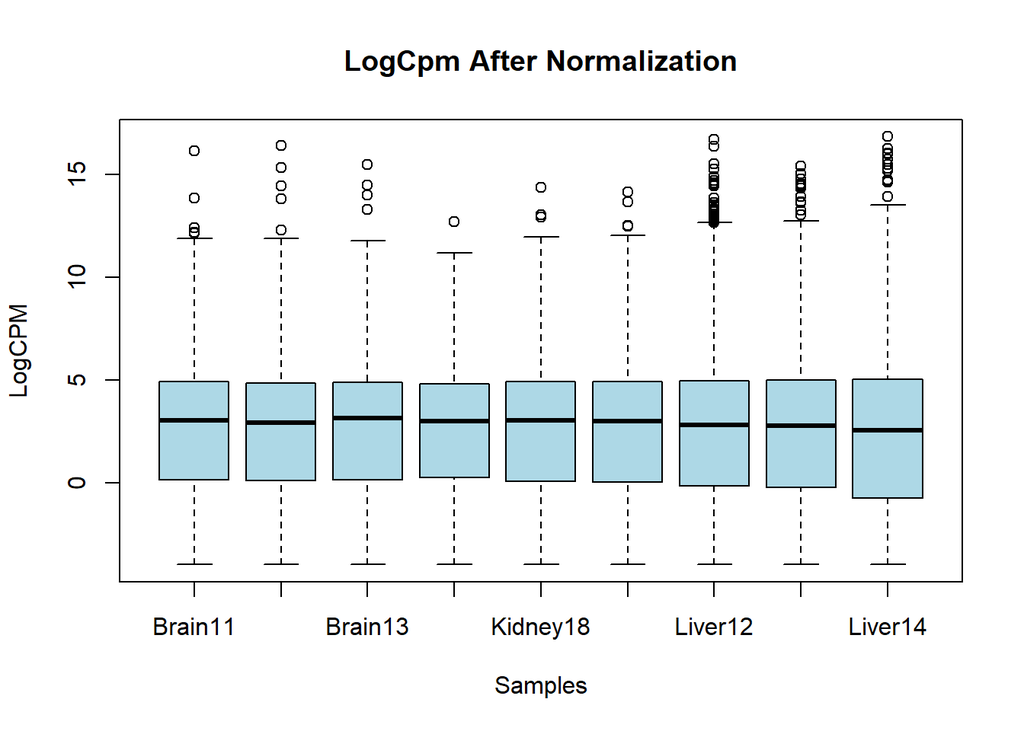

```r
boxplot(logcpm_after, main=("LogCpm After Normalization"),
        xlab= ("Samples"),
        ylab= ("LogCPM"),
        col=("lightblue"))
```

```r
design <- model.matrix(~0+group, data=y$samples)  #we modeled our matrix by without intercept because (we don't have base condition) our cells are not coming from each other unlike example of basal lp ml.

colnames(design) <- levels(y$samples$group)
design
```

```
##          Brain Kidney Liver
## Brain11      1      0     0
## Brain12      1      0     0
## Brain13      1      0     0
## Kidney17     0      1     0
## Kidney18     0      1     0
## Kidney20     0      1     0
## Liver12      0      0     1
## Liver13      0      0     1
## Liver14      0      0     1
## attr(,"assign")
## [1] 1 1 1
## attr(,"contrasts")
## attr(,"contrasts")$group
## [1] "contr.treatment"
```

```r
logcpm <- cpm(y, log=TRUE)
```

PCA Analysis:

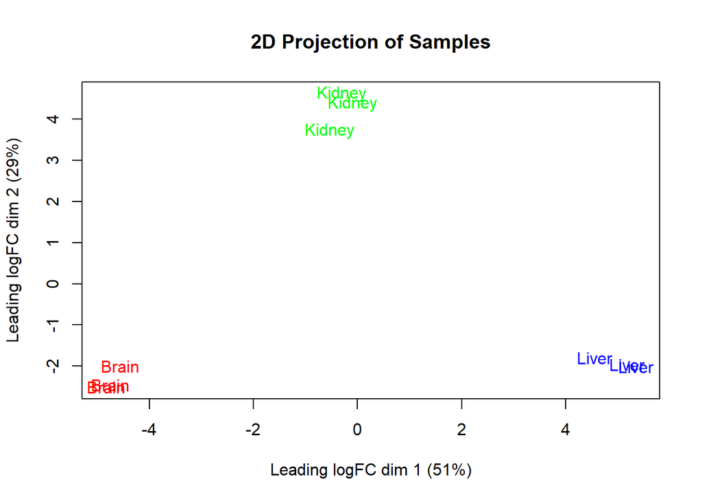

```r
plotMDS(logcpm, labels=group, main=("2D Projection of Samples"),
        col=rep(rainbow(3), each=3))
```

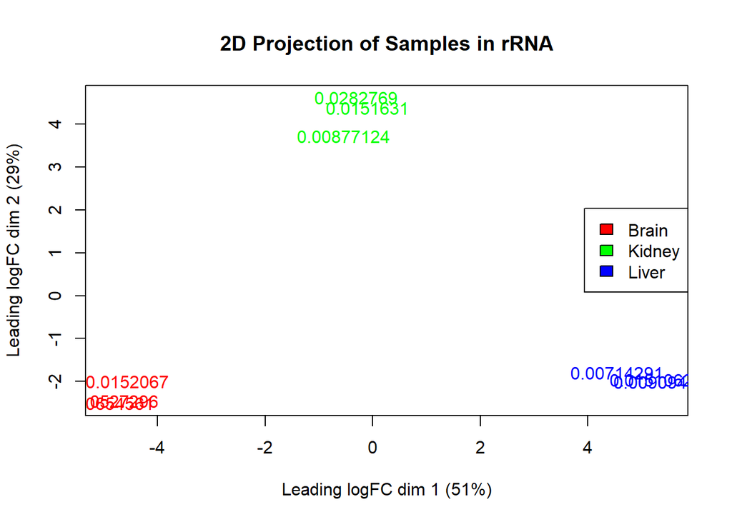

```r
plotMDS(logcpm, labels=y$samples$rRNA, main=("2D Projection of Samples in rRNA"),
        col=rep(rainbow(3), each=3))
legend("right", legend = c("Brain","Kidney","Liver"), fill = rainbow(3), cex=1)
```

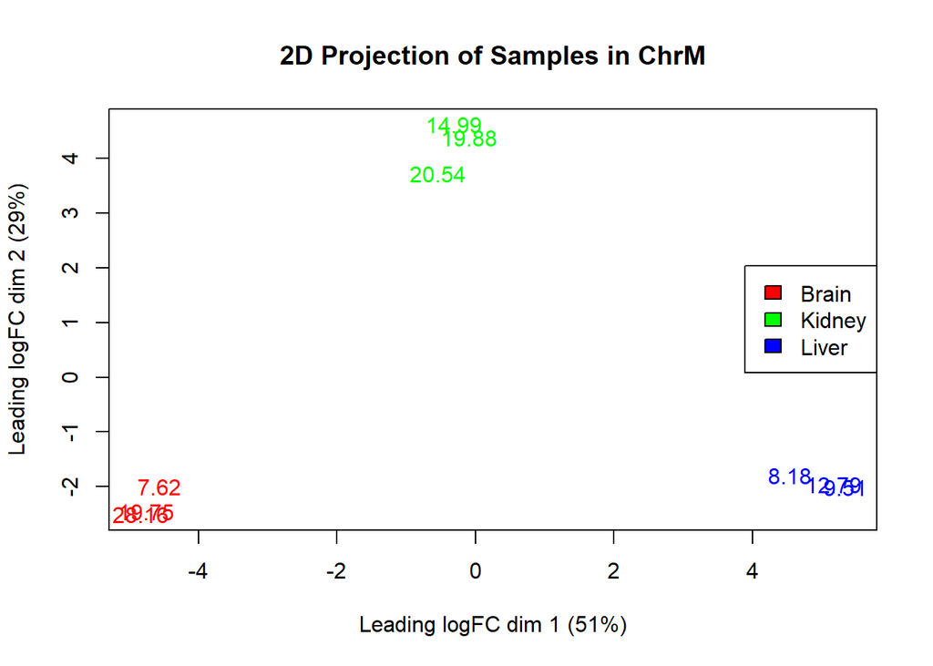

```r
plotMDS(logcpm, labels=y$samples$chrm, main=("2D Projection of Samples in ChrM"),
        col=rep(rainbow(3), each=3))
legend("right", legend = c("Brain","Kidney","Liver"), fill = rainbow(3), cex=1)
```

Differential Expression Analysis:

Estimate Dispersion: This plot explains the relationship between the average expression and the variability. Underline statistical model is NB distribution. The variance of the NB, depends on a key parameter which is called dispersion. Biological coefficient of variation is basically the square root of the dispersion. So the bigger is this coefficient, the higher variability and variance of the corresponding gene.

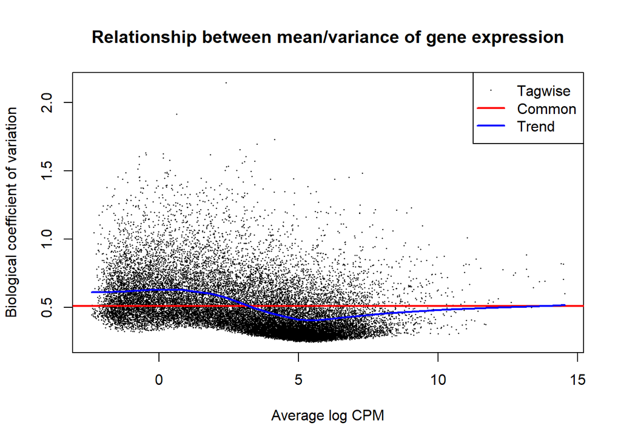

```r
y <- estimateDisp(y, design)

plotBCV(y, main=("Relationship between mean/variance of gene expression"))
```

Apply a Test to make comparison between genes in according to their expression profile;

```r
fit <- glmQLFit(y, design)

#kidney (top) vs brain (bottom)
qlfKB <- glmQLFTest(fit, contrast=c(-1,1,0)) #in this particular test, I test whether there is differential expression between top(1,kidney) bottom(-1,brain). so if they change is positive meaning more in kidney than in brain, if the change is negative it means more in brain than kidney.
#liver (top) vs brain (bottom)
qlfLB <- glmQLFTest(fit, contrast=c(-1,0,1))
#liver (top) vs kidney (bottom)
qlfLK <- glmQLFTest(fit, contrast=c(0,-1,1))


head(qlfKB$table)
```

```
##                 logFC     logCPM          F     PValue
## MIR6859-1 -0.26142119 -0.9192070 0.24372275 0.63269349
## WASH7P     0.04482044  5.0344245 0.01765494 0.89705450
## SEPT14P18 -1.21950058 -0.5001706 4.74605559 0.05563964
## CICP27     0.35781204 -1.4265604 0.47114766 0.50879280
## LOC729737 -0.65553391  4.5723506 1.02532670 0.33624286
## MIR6859-2  0.33869650 -1.3422087 0.33272689 0.57740952
```

Choose number of genes that you want to consider as a significant.

```r
summary(decideTests(qlfKB, p.value=0.05, lfc=0))
```

```
##        -1*Brain 1*Kidney
## Down                3387
## NotSig             16981
## Up                  3128
```

There are a lot of genes when we make p.value=0.05. To choose most significant genes, corrected p.value has to be more strict.

```r
summary(decideTests(qlfKB, p.value=0.01, lfc=0))
```

```
##        -1*Brain 1*Kidney
## Down                1697
## NotSig             20147
## Up                  1652
```

Try for other tissue comparisons.

```r
summary(decideTests(qlfLB, p.value=0.01, lfc=0))
```

```
##        -1*Brain 1*Liver
## Down               3438
## NotSig            17363
## Up                 2695
```

```r
summary(decideTests(qlfLK, p.value=0.01, lfc=0))
```

```
##        -1*Kidney 1*Liver
## Down                1434
## NotSig             21011
## Up                  1051
```

Write all results to the text files:

```r
resultsKB <- topTags(qlfKB, n = 10000000, adjust.method = "BH", sort.by = "PValue", p.value = 1)
write.table(resultsKB, "resultsKB.txt")

resultsLB <- topTags(qlfLB, n = 10000000, adjust.method = "BH", sort.by = "PValue", p.value = 1)
write.table(resultsLB, "resultsLB.txt")

resultsLK <- topTags(qlfLK, n = 10000000, adjust.method = "BH", sort.by = "PValue", p.value = 1)
write.table(resultsLK, "resultsLK.txt")
```

Now, create text files for the genes who are significant and upregulated on one tissue type according to others. Also, filter out genes who starts with LOC, LINC, MIR, SNORD, RPL. Also take the genes with logCPM > 0 because when it is negative it means they are in very low expression they don’t have any meaning.

```r
brain_brainvskidney <- rownames(as.data.frame(resultsKB)[as.data.frame(resultsKB)$logFC<0 & as.data.frame(resultsKB)$FDR<0.01 & as.data.frame(resultsKB)$logCPM>0,])
brain_brainvsliver <- rownames(as.data.frame(resultsLB)[as.data.frame(resultsLB)$logFC<0 & as.data.frame(resultsLB)$FDR<0.01 & as.data.frame(resultsLB)$logCPM>0,])
brain_vs_kidneyliver <- intersect(brain_brainvskidney,brain_brainvsliver)
head(brain_vs_kidneyliver)
```

```
## [1] "PMP2"   "KCNJ9"  "NCAM2"  "OLIG2"  "CACNG7" "NLGN3"
```

```r
starts = c("LOC","LINC","MIR","SNORD","RPL")

for(s in starts){
  brain_vs_kidneyliver <- brain_vs_kidneyliver[which(!startsWith(brain_vs_kidneyliver,s))]
}

write.table(brain_vs_kidneyliver,"brain_both.txt")


kidney_KB <- rownames(as.data.frame(resultsKB)[as.data.frame(resultsKB)$logFC>0 & as.data.frame(resultsKB)$FDR<0.01 & as.data.frame(resultsKB)$logCPM>0,])
kidney_LK <- rownames(as.data.frame(resultsLK)[as.data.frame(resultsLK)$logFC<0 & as.data.frame(resultsLK)$FDR<0.01 & as.data.frame(resultsLK)$logCPM>0,])
kidney_vs_BL <- intersect(kidney_KB,kidney_LK)
head(kidney_vs_BL)
```

```
## [1] "HNF1B"        "SLC44A4"      "CLDN7"        "LOC105371755" "SCNN1A"
## [6] "ITGB6"
```

```r
starts = c("LOC","LINC","MIR","SNORD","RPL")

for(s in starts){
  kidney_vs_BL <- kidney_vs_BL[which(!startsWith(kidney_vs_BL,s))]
}

write.table(kidney_vs_BL,"kidney_both.txt")



liver_LB <- rownames(as.data.frame(resultsLB)[as.data.frame(resultsLB)$logFC>0 & as.data.frame(resultsLB)$FDR<0.01 & as.data.frame(resultsLB)$logCPM>0,])
liver_LK <- rownames(as.data.frame(resultsLK)[as.data.frame(resultsLK)$logFC>0 & as.data.frame(resultsLK)$FDR<0.01 & as.data.frame(resultsLK)$logCPM>0,])
liver_vs_BK <- intersect(liver_LB,liver_LK)
head(liver_vs_BK)
```

```
## [1] "KNG1"      "HJV"       "C5-OT1"    "HSD17B2"   "MIR4751"   "MIR4751.1"
```

```r
starts = c("LOC","LINC","MIR","SNORD","RPL")

for(s in starts){
  liver_vs_BK <- liver_vs_BK[which(!startsWith(liver_vs_BK,s))]
}

write.table(liver_vs_BK,"liver_both.txt")
```

TPM ANALYSIS:

```r
library(recount)
assays(rse_brain)$TPM <- recount::getTPM(rse_brain)
assays(rse_kidney)$TPM <- recount::getTPM(rse_kidney)
assays(rse_liver)$TPM <- recount::getTPM(rse_liver)

which(rowData(rse_brain)$gene_name == "PMP2")
```

```
## [1] 48994
```

```r
which(rowData(rse_kidney)$gene_name == "HNF1B")
```

```
## [1]  3884 24999
```

```r
which(rowData(rse_liver)$gene_name == "KNG1")
```

```
## [1] 38278
```

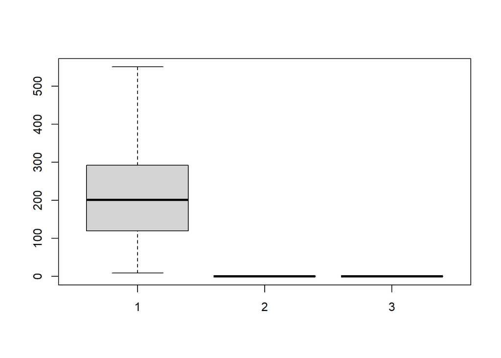

```r
boxplot(assays(rse_brain)$TPM[48994,],assays(rse_kidney)$TPM[48994,], assays(rse_liver)$TPM[48994,], outline=F )
```

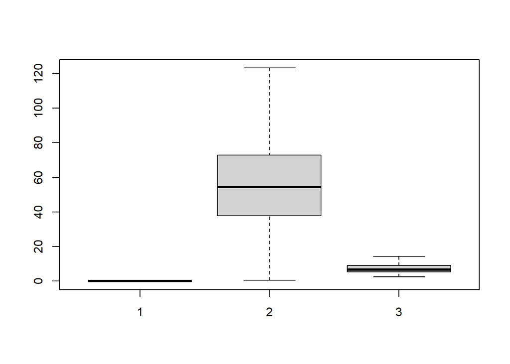

```r
boxplot(assays(rse_brain)$TPM[24999,],assays(rse_kidney)$TPM[24999,], assays(rse_liver)$TPM[24999,], outline=F )
```

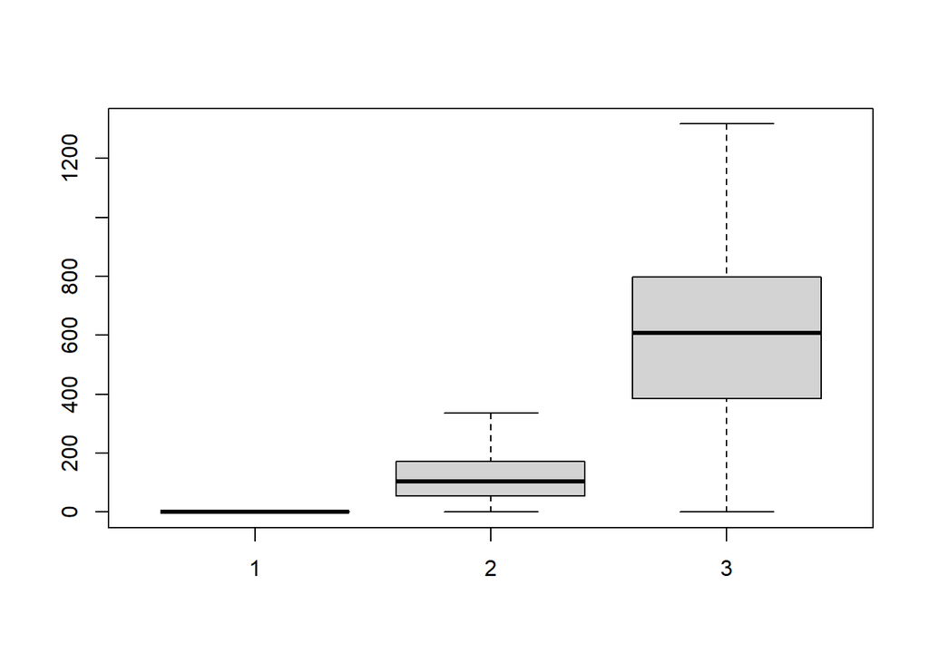

```r
boxplot(assays(rse_brain)$TPM[38278,],assays(rse_kidney)$TPM[38278,], assays(rse_liver)$TPM[38278,], outline=F )
```

TPM further :

```r
library(ggpubr)
library(rstatix)
which(rowData(rse_brain)$gene_name == "NCAM2")
```

```
## [1] 34292
```

```r
df_brain=data.frame(TPM=assays(rse_brain)$TPM[34292,],group="Brain")
df_kidney=data.frame(TPM=assays(rse_kidney)$TPM[34292,],group="Kidney")
df_liver=data.frame(TPM=assays(rse_liver)$TPM[34292,],group="Liver")

data_NCAM2=rbind(df_brain,df_kidney,df_liver)


pwc2=data_NCAM2 %>% wilcox_test(TPM ~ group, p.adjust.method = "BH")
pwc2
```

```
## # A tibble: 3 × 9
##   .y.   group1 group2    n1    n2 statistic         p     p.adj p.adj.signif
## * <chr> <chr>  <chr>  <int> <int>     <dbl>     <dbl>     <dbl> <chr>
## 1 TPM   Brain  Kidney  2931    98    287236 8.32e- 64 1.25e- 63 ****
## 2 TPM   Brain  Liver   2931   251    728021 1.35e-146 4.05e-146 ****
## 3 TPM   Kidney Liver     98   251     10258 1.6 e-  2 1.6 e-  2 *
```

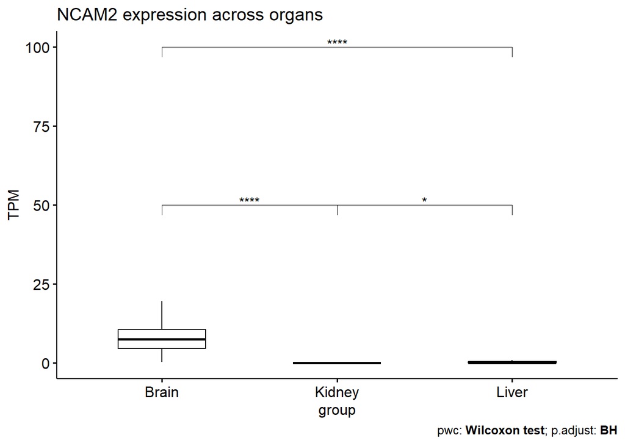

```r
pwc = pwc2 %>% add_xy_position(x = "group") #Auto-compute p-value label positions
ggboxplot(data_NCAM2, x = "group", y = "TPM", outlier.shape =NA, width = 0.5,title="NCAM2 expression across organs") +
  stat_pvalue_manual(pwc,y.position = c(50,100,50)) + #Add the p-values to the plot
  labs(caption = get_pwc_label(pwc))
```

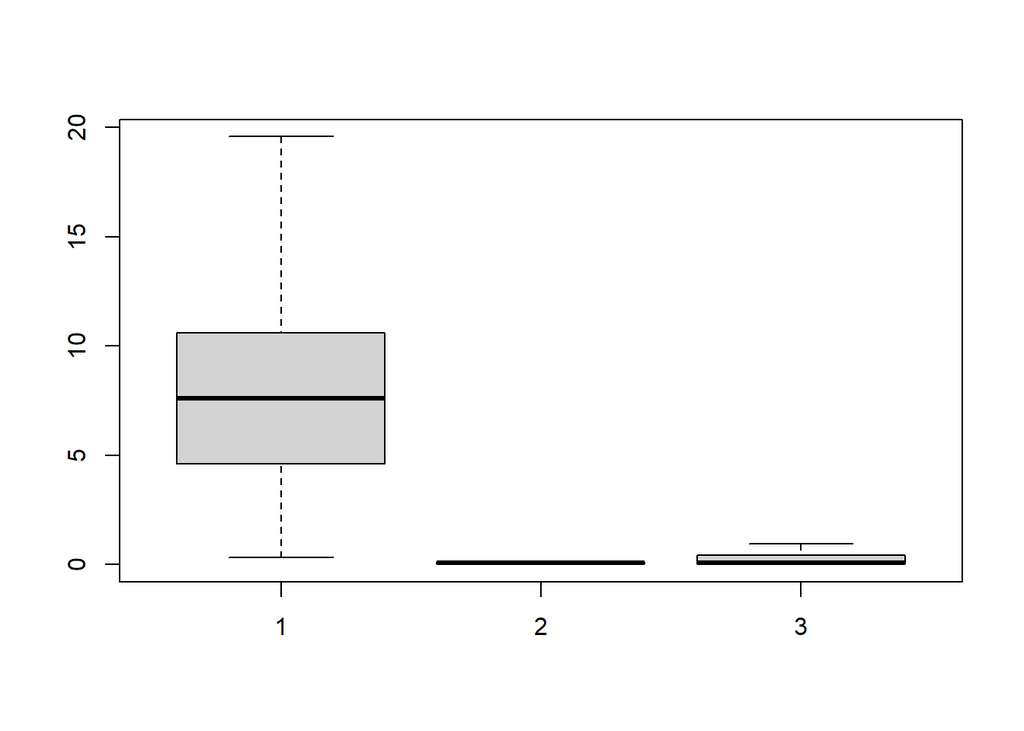

```r
boxplot(assays(rse_brain)$TPM[34292,],assays(rse_kidney)$TPM[34292,], assays(rse_liver)$TPM[34292,], outline=F )
```